# Project 1

Ruben Sowah

2022-09-10

#### Data Processing

```r
library(tidyverse)
library(readr)
sheet1 <- read_csv("https://www4.stat.ncsu.edu/~online/datasets/EDU01a.csv")
print(sheet1, n=5)
```

```
## # A tibble: 3,198 x 42
##   Area_n~1 STCOU EDU01~2 EDU01~3 EDU01~4 EDU01~5 EDU01~6 EDU01~7 EDU01~8 EDU01~9
##   <chr>    <chr>   <dbl>   <dbl> <chr>   <chr>     <dbl>   <dbl> <chr>   <chr>
## 1 UNITED ~ 00000       0  4.00e7 0000    0000          0  4.00e7 0000    0000
## 2 ALABAMA  01000       0  7.34e5 0000    0000          0  7.28e5 0000    0000
## 3 Autauga~ 01001       0  6.83e3 0000    0000          0  6.9 e3 0000    0000
## 4 Baldwin~ 01003       0  1.64e4 0000    0000          0  1.65e4 0000    0000
## 5 Barbour~ 01005       0  5.07e3 0000    0000          0  5.10e3 0000    0000
## # ... with 3,193 more rows, 32 more variables: EDU010189F <dbl>,
## #   EDU010189D <dbl>, EDU010189N1 <chr>, EDU010189N2 <chr>, EDU010190F <dbl>,
## #   EDU010190D <dbl>, EDU010190N1 <chr>, EDU010190N2 <chr>, EDU010191F <dbl>,
## #   EDU010191D <dbl>, EDU010191N1 <chr>, EDU010191N2 <chr>, EDU010192F <dbl>,
## #   EDU010192D <dbl>, EDU010192N1 <chr>, EDU010192N2 <chr>, EDU010193F <dbl>,
## #   EDU010193D <dbl>, EDU010193N1 <chr>, EDU010193N2 <chr>, EDU010194F <dbl>,
## #   EDU010194D <dbl>, EDU010194N1 <chr>, EDU010194N2 <chr>, ...
```

```r
names(sheet1)
```

```
##  [1] "Area_name"   "STCOU"       "EDU010187F"  "EDU010187D"  "EDU010187N1"
##  [6] "EDU010187N2" "EDU010188F"  "EDU010188D"  "EDU010188N1" "EDU010188N2"
## [11] "EDU010189F"  "EDU010189D"  "EDU010189N1" "EDU010189N2" "EDU010190F"
## [16] "EDU010190D"  "EDU010190N1" "EDU010190N2" "EDU010191F"  "EDU010191D"
## [21] "EDU010191N1" "EDU010191N2" "EDU010192F"  "EDU010192D"  "EDU010192N1"
## [26] "EDU010192N2" "EDU010193F"  "EDU010193D"  "EDU010193N1" "EDU010193N2"
## [31] "EDU010194F"  "EDU010194D"  "EDU010194N1" "EDU010194N2" "EDU010195F"
## [36] "EDU010195D"  "EDU010195N1" "EDU010195N2" "EDU010196F"  "EDU010196D"
## [41] "EDU010196N1" "EDU010196N2"
```

1 ) Select only the Area_name(renamed as area_name),STCOU columns and any variable that ends in “D”

```r
sheet <- sheet1 %>%
          rename(area_name = Area_name) %>%
          select(area_name, STCOU, ends_with("D"))
print(sheet , n = 5, width = 100)
```

```
## # A tibble: 3,198 x 12
##   area_name     STCOU EDU010187D EDU010188D EDU010189D EDU010190D EDU010191D
##   <chr>         <chr>      <dbl>      <dbl>      <dbl>      <dbl>      <dbl>
## 1 UNITED STATES 00000   40024299   39967624   40317775   40737600   41385442
## 2 ALABAMA       01000     733735     728234     730048     728252     725541
## 3 Autauga, AL   01001       6829       6900       6920       6847       7008
## 4 Baldwin, AL   01003      16417      16465      16799      17054      17479
## 5 Barbour, AL   01005       5071       5098       5068       5156       5173
##   EDU010192D EDU010193D EDU010194D EDU010195D EDU010196D
##        <dbl>      <dbl>      <dbl>      <dbl>      <dbl>
## 1   42088151   42724710   43369917   43993459   44715737
## 2     726150     728014     730509     727989     736825
## 3       7137       7152       7381       7568       7834
## 4      17983      18735      19384      19961      20699
## 5       5252       5135       5111       5017       5053
## # ... with 3,193 more rows
```

```r
names(sheet)
```

```
##  [1] "area_name"  "STCOU"      "EDU010187D" "EDU010188D" "EDU010189D"
##  [6] "EDU010190D" "EDU010191D" "EDU010192D" "EDU010193D" "EDU010194D"
## [11] "EDU010195D" "EDU010196D"
```

2 ) Convert the data into long format where each row has only one enrollment value for that area_name

```r
sheet <- sheet %>%
          pivot_longer(cols= ends_with('D'), names_to = 'enrollment', values_to = 'enrolValue')
print(sheet, n= 5)
```

```
## # A tibble: 31,980 x 4
##   area_name     STCOU enrollment enrolValue
##   <chr>         <chr> <chr>           <dbl>
## 1 UNITED STATES 00000 EDU010187D   40024299
## 2 UNITED STATES 00000 EDU010188D   39967624
## 3 UNITED STATES 00000 EDU010189D   40317775
## 4 UNITED STATES 00000 EDU010190D   40737600
## 5 UNITED STATES 00000 EDU010191D   41385442
## # ... with 31,975 more rows
```

3 ) Create new variables, *year* and *surveyID* from the *enrollment* variable

```r
sheet <- sheet %>%
          mutate(
                 surveyID =(substr(enrollment, start = 1, stop = 7)),
                 year = as.numeric(format(as.Date((substr(enrollment,8,9)),'%y'),'%Y')),
            )

print(sheet, n = 30)
```

```
## # A tibble: 31,980 x 6
##    area_name     STCOU enrollment enrolValue surveyID  year
##    <chr>         <chr> <chr>           <dbl> <chr>    <dbl>
##  1 UNITED STATES 00000 EDU010187D   40024299 EDU0101   1987
##  2 UNITED STATES 00000 EDU010188D   39967624 EDU0101   1988
##  3 UNITED STATES 00000 EDU010189D   40317775 EDU0101   1989
##  4 UNITED STATES 00000 EDU010190D   40737600 EDU0101   1990
##  5 UNITED STATES 00000 EDU010191D   41385442 EDU0101   1991
##  6 UNITED STATES 00000 EDU010192D   42088151 EDU0101   1992
##  7 UNITED STATES 00000 EDU010193D   42724710 EDU0101   1993
##  8 UNITED STATES 00000 EDU010194D   43369917 EDU0101   1994
##  9 UNITED STATES 00000 EDU010195D   43993459 EDU0101   1995
## 10 UNITED STATES 00000 EDU010196D   44715737 EDU0101   1996
## 11 ALABAMA       01000 EDU010187D     733735 EDU0101   1987
## 12 ALABAMA       01000 EDU010188D     728234 EDU0101   1988
```

[output cut: 19 more lines]

4) Create two data sets *noctData* and *ctData* that contain non-county data and county level data, respectively

```r
## Use the grep function to get the row indices of the counties
index <- (grep(pattern = ", \\w\\w", sheet$area_name))

## The county data is all the observations that correspond to the above rows,
##  and the state data is all the remaining observations
ctData <- sheet[index,]
noctData <- sheet[-index,]

## Add the class county and state respectively to the county level and non-county level datas;
class(ctData) <- c("county", class(ctData))
class(noctData) <- c("state", class(noctData))

print(ctData, n = 5); attributes(ctData)[[3]]
```

```
## # A tibble: 31,450 x 6
##   area_name   STCOU enrollment enrolValue surveyID  year
##   <chr>       <chr> <chr>           <dbl> <chr>    <dbl>
## 1 Autauga, AL 01001 EDU010187D       6829 EDU0101   1987
## 2 Autauga, AL 01001 EDU010188D       6900 EDU0101   1988
## 3 Autauga, AL 01001 EDU010189D       6920 EDU0101   1989
## 4 Autauga, AL 01001 EDU010190D       6847 EDU0101   1990
## 5 Autauga, AL 01001 EDU010191D       7008 EDU0101   1991
## # ... with 31,445 more rows
```

```
## [1] "county"     "tbl_df"     "tbl"        "data.frame"
```

```r
print(noctData, n = 5); (attributes(noctData)[[3]])
```

```
## # A tibble: 530 x 6
##   area_name     STCOU enrollment enrolValue surveyID  year
##   <chr>         <chr> <chr>           <dbl> <chr>    <dbl>
## 1 UNITED STATES 00000 EDU010187D   40024299 EDU0101   1987
## 2 UNITED STATES 00000 EDU010188D   39967624 EDU0101   1988
## 3 UNITED STATES 00000 EDU010189D   40317775 EDU0101   1989
## 4 UNITED STATES 00000 EDU010190D   40737600 EDU0101   1990
## 5 UNITED STATES 00000 EDU010191D   41385442 EDU0101   1991
## # ... with 525 more rows
```

```
## [1] "state"      "tbl_df"     "tbl"        "data.frame"
```

5) For the county level tibble, create a new variable that describes which state one of these county measurements corresponds to.

```r
ctData <- ctData %>%
          mutate(var = (substr(STCOU , 1,2)))
print(ctData, n = 10)
```

```
## # A tibble: 31,450 x 7
##    area_name   STCOU enrollment enrolValue surveyID  year var
##    <chr>       <chr> <chr>           <dbl> <chr>    <dbl> <chr>
##  1 Autauga, AL 01001 EDU010187D       6829 EDU0101   1987 01
##  2 Autauga, AL 01001 EDU010188D       6900 EDU0101   1988 01
##  3 Autauga, AL 01001 EDU010189D       6920 EDU0101   1989 01
##  4 Autauga, AL 01001 EDU010190D       6847 EDU0101   1990 01
##  5 Autauga, AL 01001 EDU010191D       7008 EDU0101   1991 01
##  6 Autauga, AL 01001 EDU010192D       7137 EDU0101   1992 01
##  7 Autauga, AL 01001 EDU010193D       7152 EDU0101   1993 01
##  8 Autauga, AL 01001 EDU010194D       7381 EDU0101   1994 01
##  9 Autauga, AL 01001 EDU010195D       7568 EDU0101   1995 01
## 10 Autauga, AL 01001 EDU010196D       7834 EDU0101   1996 01
## # ... with 31,440 more rows
```

6) For the non-county level tibble, create a new variable *division* corresponding to the state’s classification of division.

```r
#a<- `%in%`(noctData$area_name,'CONNECTICUT')#

noctData <- noctData %>%
              mutate(division = if_else(area_name %in% c('CONNECTICUT','MAINE','MASSACHUSETTS','NEW HAMPSHIRE','RHODE ISLAND','VERMONT'),"Division 1",
                                        if_else(area_name %in% c('NEW JERSEY','NEW YORK','PENNSYLVANIA'),"Division 2",
                                                if_else(area_name %in% c('ILLINOIS','INDIANA','MICHIGAN','OHIO','WISCONSIN'),"Division 3",
                                                        if_else(area_name %in% c('IOWA','KANSAS','MINNESOTA','MISSOURI','NEBRASKA','NORTH DAKOTA','SOUTH DAKOTA'),"Division 4",
                                                                if_else(area_name %in% c('DELAWARE','FLORIDA','GEORGIA','MARYLAND','NORTH CAROLINA','SOUTH CAROLINA','VIRGINIA','WASHINGTON,D.C','WEST VIRGINIA'),"Division 5",
                                                                        if_else(area_name %in% c('ALABAMA','KENTUCKY','MISSISSIPPI','TENNESSEE'),"Division 6",
                                                                                if_else(area_name %in% c('ARKANSAS','LOUISIANA','OKLAHOMA','TEXAS'),"Division 7",
                                                                                        if_else(area_name %in% c('ARIZONA','COLORADO','IDAHO','MONTANA','NEVADA','NEW MEXICO','UTAH','WYOMING'),"Division 8",
                                                                                                if_else(area_name %in% c('ALASKA','CALIFORNIA','HAWAII','OREGON','WASHINGTON'),"Division 9", "Error"))))))))))

print(noctData, n = 12)
```

```
## # A tibble: 530 x 7
##    area_name     STCOU enrollment enrolValue surveyID  year division
##    <chr>         <chr> <chr>           <dbl> <chr>    <dbl> <chr>
##  1 UNITED STATES 00000 EDU010187D   40024299 EDU0101   1987 Error
##  2 UNITED STATES 00000 EDU010188D   39967624 EDU0101   1988 Error
##  3 UNITED STATES 00000 EDU010189D   40317775 EDU0101   1989 Error
##  4 UNITED STATES 00000 EDU010190D   40737600 EDU0101   1990 Error
##  5 UNITED STATES 00000 EDU010191D   41385442 EDU0101   1991 Error
##  6 UNITED STATES 00000 EDU010192D   42088151 EDU0101   1992 Error
##  7 UNITED STATES 00000 EDU010193D   42724710 EDU0101   1993 Error
##  8 UNITED STATES 00000 EDU010194D   43369917 EDU0101   1994 Error
##  9 UNITED STATES 00000 EDU010195D   43993459 EDU0101   1995 Error
## 10 UNITED STATES 00000 EDU010196D   44715737 EDU0101   1996 Error
## 11 ALABAMA       01000 EDU010187D     733735 EDU0101   1987 Division 6
## 12 ALABAMA       01000 EDU010188D     728234 EDU0101   1988 Division 6
## # ... with 518 more rows
```

#### Data Processing Function

```r
mydata <- read_csv("https://www4.stat.ncsu.edu/~online/datasets/EDU01b.csv")
mydata <- rename(mydata, area_name = Area_name)
names(mydata)
```

```
##  [1] "area_name"   "STCOU"       "EDU010197F"  "EDU010197D"  "EDU010197N1"
##  [6] "EDU010197N2" "EDU010198F"  "EDU010198D"  "EDU010198N1" "EDU010198N2"
## [11] "EDU010199F"  "EDU010199D"  "EDU010199N1" "EDU010199N2" "EDU010200F"
## [16] "EDU010200D"  "EDU010200N1" "EDU010200N2" "EDU010201F"  "EDU010201D"
## [21] "EDU010201N1" "EDU010201N2" "EDU010202F"  "EDU010202D"  "EDU010202N1"
## [26] "EDU010202N2" "EDU015203F"  "EDU015203D"  "EDU015203N1" "EDU015203N2"
## [31] "EDU015204F"  "EDU015204D"  "EDU015204N1" "EDU015204N2" "EDU015205F"
## [36] "EDU015205D"  "EDU015205N1" "EDU015205N2" "EDU015206F"  "EDU015206D"
## [41] "EDU015206N1" "EDU015206N2"
```

- Write a function that does steps 1 and 2 above.

```r
## Write a function that only select the desired columns
function_f <- function(data, col1, col2, col3 = ...) {
  #f1 <- rename(mydata, area_name = col1)
  f2 <- select(mydata,col1,col2,col3)
  f3 <- pivot_longer(f2,cols = col3,names_to = 'enrollment' ,values_to = 'enrolValue')
  return(f3)
}
f4 <- (function_f(data = mydata,col1= "area_name", col2 = "STCOU",col3 = c("EDU010197D","EDU010198D","EDU010199D","EDU010200D","EDU010201D", "EDU010202D", "EDU015203D","EDU015204D","EDU015205D","EDU015206D")))

print(f4, n=8)
```

```
## # A tibble: 31,980 x 4
##   area_name     STCOU enrollment enrolValue
##   <chr>         <chr> <chr>           <dbl>
## 1 UNITED STATES 00000 EDU010197D   44534459
## 2 UNITED STATES 00000 EDU010198D   46245814
## 3 UNITED STATES 00000 EDU010199D   46368903
## 4 UNITED STATES 00000 EDU010200D   46818690
## 5 UNITED STATES 00000 EDU010201D   47127066
## 6 UNITED STATES 00000 EDU010202D   47606570
## 7 UNITED STATES 00000 EDU015203D   48506317
## 8 UNITED STATES 00000 EDU015204D   48693287
## # ... with 31,972 more rows
```

- Write another function that takes in the output of step 2 and does step 3 above.

```r
function_g <- function(f4){

  g1 <- mutate(f4,surveyID =(substr(f4[[3]], start = 1, stop = 7)),year=as.numeric(format(as.Date((substr(f4[[3]],8,9)),'%y'),'%Y')),)
  return(g1)
}
g2 <- (function_g(f4)); print(g2, n=10)
```

```
## # A tibble: 31,980 x 6
##    area_name     STCOU enrollment enrolValue surveyID  year
##    <chr>         <chr> <chr>           <dbl> <chr>    <dbl>
##  1 UNITED STATES 00000 EDU010197D   44534459 EDU0101   1997
##  2 UNITED STATES 00000 EDU010198D   46245814 EDU0101   1998
##  3 UNITED STATES 00000 EDU010199D   46368903 EDU0101   1999
##  4 UNITED STATES 00000 EDU010200D   46818690 EDU0102   2000
##  5 UNITED STATES 00000 EDU010201D   47127066 EDU0102   2001
##  6 UNITED STATES 00000 EDU010202D   47606570 EDU0102   2002
##  7 UNITED STATES 00000 EDU015203D   48506317 EDU0152   2003
##  8 UNITED STATES 00000 EDU015204D   48693287 EDU0152   2004
##  9 UNITED STATES 00000 EDU015205D   48978555 EDU0152   2005
## 10 UNITED STATES 00000 EDU015206D   49140702 EDU0152   2006
## # ... with 31,970 more rows
```

- Write another function that takes in the output from step 3 and creates the two tibbles in step 4, calls the above two functions (to perform steps 5 and 6), and returns two final tibbles.

```r
function_h <- function(g2){
  index <- (grep(pattern = ", \\w\\w", g2$area_name))
  ctData <- g2[index,]
  noctData <- g2[-index,]

  class(ctData) <- c("county", class(ctData))
  class(noctData) <- c("state", class(noctData))

  return(list(ctData,noctData))
}
h <- (function_h(g2)); print(h)
```

```
## [[1]]
## # A tibble: 31,450 x 6
##    area_name   STCOU enrollment enrolValue surveyID  year
##    <chr>       <chr> <chr>           <dbl> <chr>    <dbl>
##  1 Autauga, AL 01001 EDU010197D       8099 EDU0101   1997
##  2 Autauga, AL 01001 EDU010198D       8211 EDU0101   1998
##  3 Autauga, AL 01001 EDU010199D       8489 EDU0101   1999
##  4 Autauga, AL 01001 EDU010200D       8912 EDU0102   2000
##  5 Autauga, AL 01001 EDU010201D       8626 EDU0102   2001
##  6 Autauga, AL 01001 EDU010202D       8762 EDU0102   2002
##  7 Autauga, AL 01001 EDU015203D       9105 EDU0152   2003
##  8 Autauga, AL 01001 EDU015204D       9200 EDU0152   2004
##  9 Autauga, AL 01001 EDU015205D       9559 EDU0152   2005
## 10 Autauga, AL 01001 EDU015206D       9652 EDU0152   2006
## # ... with 31,440 more rows
##
## [[2]]
## # A tibble: 530 x 6
##    area_name     STCOU enrollment enrolValue surveyID  year
##    <chr>         <chr> <chr>           <dbl> <chr>    <dbl>
##  1 UNITED STATES 00000 EDU010197D   44534459 EDU0101   1997
##  2 UNITED STATES 00000 EDU010198D   46245814 EDU0101   1998
##  3 UNITED STATES 00000 EDU010199D   46368903 EDU0101   1999
##  4 UNITED STATES 00000 EDU010200D   46818690 EDU0102   2000
##  5 UNITED STATES 00000 EDU010201D   47127066 EDU0102   2001
##  6 UNITED STATES 00000 EDU010202D   47606570 EDU0102   2002
##  7 UNITED STATES 00000 EDU015203D   48506317 EDU0152   2003
##  8 UNITED STATES 00000 EDU015204D   48693287 EDU0152   2004
##  9 UNITED STATES 00000 EDU015205D   48978555 EDU0152   2005
## 10 UNITED STATES 00000 EDU015206D   49140702 EDU0152   2006
## # ... with 520 more rows
```

- Write a function to do step 5

```r
function_i <- function(g2){
  ctData <- mutate(g2,var=(substr(g2[[2]],1,2)))
  return(ctData)
}
i <- function_i(g2);print(i, n=10)
```

```
## # A tibble: 31,980 x 7
##    area_name     STCOU enrollment enrolValue surveyID  year var
##    <chr>         <chr> <chr>           <dbl> <chr>    <dbl> <chr>
##  1 UNITED STATES 00000 EDU010197D   44534459 EDU0101   1997 00
##  2 UNITED STATES 00000 EDU010198D   46245814 EDU0101   1998 00
##  3 UNITED STATES 00000 EDU010199D   46368903 EDU0101   1999 00
##  4 UNITED STATES 00000 EDU010200D   46818690 EDU0102   2000 00
##  5 UNITED STATES 00000 EDU010201D   47127066 EDU0102   2001 00
##  6 UNITED STATES 00000 EDU010202D   47606570 EDU0102   2002 00
##  7 UNITED STATES 00000 EDU015203D   48506317 EDU0152   2003 00
##  8 UNITED STATES 00000 EDU015204D   48693287 EDU0152   2004 00
##  9 UNITED STATES 00000 EDU015205D   48978555 EDU0152   2005 00
## 10 UNITED STATES 00000 EDU015206D   49140702 EDU0152   2006 00
## # ... with 31,970 more rows
```

- Write a function to do step 6

```r
function_j <- function(g2){
  noctData <- mutate(g2,division = if_else(area_name %in% c('CONNECTICUT','MAINE','MASSACHUSETTS','NEW HAMPSHIRE','RHODE ISLAND','VERMONT'),"Division 1",
                                        if_else(area_name %in% c('NEW JERSEY','NEW YORK','PENNSYLVANIA'),"Division 2",
                                                if_else(area_name %in% c('ILLINOIS','INDIANA','MICHIGAN','OHIO','WISCONSIN'),"Division 3",
                                                        if_else(area_name %in% c('IOWA','KANSAS','MINNESOTA','MISSOURI','NEBRASKA','NORTH DAKOTA','SOUTH DAKOTA'),"Division 4",
                                                                if_else(area_name %in% c('DELAWARE','FLORIDA','GEORGIA','MARYLAND','NORTH CAROLINA','SOUTH CAROLINA','VIRGINIA','WASHINGTON,D.C','WEST VIRGINIA'),"Division 5",
                                                                        if_else(area_name %in% c('ALABAMA','KENTUCKY','MISSISSIPPI','TENNESSEE'),"Division 6",
                                                                                if_else(area_name %in% c('ARKANSAS','LOUISIANA','OKLAHOMA','TEXAS'),"Division 7",
                                                                                        if_else(area_name %in% c('ARIZONA','COLORADO','IDAHO','MONTANA','NEVADA','NEW MEXICO','UTAH','WYOMING'),"Division 8",
                                                                                                if_else(area_name %in% c('ALASKA','CALIFORNIA','HAWAII','OREGON','WASHINGTON'),"Division 9", "Error"))))))))))
  return(noctData)
}
j <- function_j(g2); print(j, n=10)
```

```
## # A tibble: 31,980 x 7
##    area_name     STCOU enrollment enrolValue surveyID  year division
##    <chr>         <chr> <chr>           <dbl> <chr>    <dbl> <chr>
##  1 UNITED STATES 00000 EDU010197D   44534459 EDU0101   1997 Error
##  2 UNITED STATES 00000 EDU010198D   46245814 EDU0101   1998 Error
##  3 UNITED STATES 00000 EDU010199D   46368903 EDU0101   1999 Error
##  4 UNITED STATES 00000 EDU010200D   46818690 EDU0102   2000 Error
##  5 UNITED STATES 00000 EDU010201D   47127066 EDU0102   2001 Error
##  6 UNITED STATES 00000 EDU010202D   47606570 EDU0102   2002 Error
##  7 UNITED STATES 00000 EDU015203D   48506317 EDU0152   2003 Error
##  8 UNITED STATES 00000 EDU015204D   48693287 EDU0152   2004 Error
##  9 UNITED STATES 00000 EDU015205D   48978555 EDU0152   2005 Error
## 10 UNITED STATES 00000 EDU015206D   49140702 EDU0152   2006 Error
## # ... with 31,970 more rows
```

- Wrapper function

```r
my_wrapper <- function(url, var_name = ...){
  a <- read_csv(url)

  b <- function(a,col1,col2,col3 = ...){
        b1 <- select(a,col1,col2,col3)
        b2 <- pivot_longer(b1,cols = col3,names_to = 'enrollment' ,values_to = 'enrolValue')
  return(b2)
  }

  c1 <- function(b){
    c2 <- mutate(b,surveyID =(substr(b[[3]], start = 1, stop = 7)),year=as.numeric(format(as.Date((substr(b[[3]],8,9)),'%y'),'%Y')),)
  return(c2)
  }

  d <- function(c1){
    index <- (grep(pattern = ", \\w\\w", c1$area_name))
    ctData <- c1[index,]
    noctData <- c1[-index,]

    class(ctData) <- c("county", class(ctData))
    class(noctData) <- c("state", class(noctData))

    ctData <- mutate(c1,var=(substr(c1[[2]],1,2)))
    noctData <- mutate(c1,division = if_else(area_name %in% c('CONNECTICUT','MAINE','MASSACHUSETTS','NEW HAMPSHIRE','RHODE ISLAND','VERMONT'),"Division 1",
                                        if_else(area_name %in% c('NEW JERSEY','NEW YORK','PENNSYLVANIA'),"Division 2",
                                                if_else(area_name %in% c('ILLINOIS','INDIANA','MICHIGAN','OHIO','WISCONSIN'),"Division 3",
                                                        if_else(area_name %in% c('IOWA','KANSAS','MINNESOTA','MISSOURI','NEBRASKA','NORTH DAKOTA','SOUTH DAKOTA'),"Division 4",
                                                                if_else(area_name %in% c('DELAWARE','FLORIDA','GEORGIA','MARYLAND','NORTH CAROLINA','SOUTH CAROLINA','VIRGINIA','WASHINGTON,D.C','WEST VIRGINIA'),"Division 5",
                                                                        if_else(area_name %in% c('ALABAMA','KENTUCKY','MISSISSIPPI','TENNESSEE'),"Division 6",
                                                                                if_else(area_name %in% c('ARKANSAS','LOUISIANA','OKLAHOMA','TEXAS'),"Division 7",
                                                                                        if_else(area_name %in% c('ARIZONA','COLORADO','IDAHO','MONTANA','NEVADA','NEW MEXICO','UTAH','WYOMING'),"Division 8",
                                                                                                if_else(area_name %in% c('ALASKA','CALIFORNIA','HAWAII','OREGON','WASHINGTON'),"Division 9", "Error"))))))))))

  }
 return(list(ctData,noctData))
}
```

#### Call It and Combine Your Data

```r
wrap_a <- (my_wrapper(("https://www4.stat.ncsu.edu/~online/datasets/EDU01a.csv")))

wrap_b <- (my_wrapper(("https://www4.stat.ncsu.edu/~online/datasets/EDU01b.csv")))

combine <- function(x,y){

   comb1 <- dplyr::bind_rows(x[[1]], y[[1]])
   comb2 <- dplyr::bind_rows(x[[2]], y[[2]])
   return(list(comb1,comb2))
}
Both_combined <- combine(x = wrap_a, y = wrap_b)
Both_combined
```

```
## [[1]]
## # A tibble: 62,900 x 7
##    area_name   STCOU enrollment enrolValue surveyID  year var
##    <chr>       <chr> <chr>           <dbl> <chr>    <dbl> <chr>
##  1 Autauga, AL 01001 EDU010187D       6829 EDU0101   1987 01
##  2 Autauga, AL 01001 EDU010188D       6900 EDU0101   1988 01
##  3 Autauga, AL 01001 EDU010189D       6920 EDU0101   1989 01
##  4 Autauga, AL 01001 EDU010190D       6847 EDU0101   1990 01
##  5 Autauga, AL 01001 EDU010191D       7008 EDU0101   1991 01
##  6 Autauga, AL 01001 EDU010192D       7137 EDU0101   1992 01
##  7 Autauga, AL 01001 EDU010193D       7152 EDU0101   1993 01
##  8 Autauga, AL 01001 EDU010194D       7381 EDU0101   1994 01
##  9 Autauga, AL 01001 EDU010195D       7568 EDU0101   1995 01
## 10 Autauga, AL 01001 EDU010196D       7834 EDU0101   1996 01
## # ... with 62,890 more rows
##
## [[2]]
## # A tibble: 1,060 x 7
##    area_name     STCOU enrollment enrolValue surveyID  year division
##    <chr>         <chr> <chr>           <dbl> <chr>    <dbl> <chr>
##  1 UNITED STATES 00000 EDU010187D   40024299 EDU0101   1987 Error
##  2 UNITED STATES 00000 EDU010188D   39967624 EDU0101   1988 Error
##  3 UNITED STATES 00000 EDU010189D   40317775 EDU0101   1989 Error
##  4 UNITED STATES 00000 EDU010190D   40737600 EDU0101   1990 Error
##  5 UNITED STATES 00000 EDU010191D   41385442 EDU0101   1991 Error
##  6 UNITED STATES 00000 EDU010192D   42088151 EDU0101   1992 Error
##  7 UNITED STATES 00000 EDU010193D   42724710 EDU0101   1993 Error
##  8 UNITED STATES 00000 EDU010194D   43369917 EDU0101   1994 Error
##  9 UNITED STATES 00000 EDU010195D   43993459 EDU0101   1995 Error
## 10 UNITED STATES 00000 EDU010196D   44715737 EDU0101   1996 Error
## # ... with 1,050 more rows
```

#### Writing a Generic Function for Summarizing

##### * State

```r
plot.state <- function(df, var_name = ...){
dat1 <- df %>%
        select( enrolValue, year,division) %>%
        filter(division != 'Error') %>%
        group_by(division,year) %>%
        summarise(avg = mean(enrolValue))


 ggplot(dat1, aes(x = dat1$year, y = dat1$avg, color = division)) +
geom_line()


}
plot.state(df = Both_combined[[2]])
```

[output not shown]

##### * County

```
## [[1]]
## # A tibble: 31,400 x 3
## # Groups:   area_name [3,140]
##    area_name        year avgState
##    <chr>           <dbl>    <dbl>
##  1 Los Angeles, CA  1996  1508589
##  2 Los Angeles, CA  1995  1473717
##  3 Los Angeles, CA  1994  1465597
##  4 Los Angeles, CA  1993  1455867
##  5 Los Angeles, CA  1992  1441228
##  6 Los Angeles, CA  1991  1406705
##  7 Los Angeles, CA  1989  1404930
##  8 Los Angeles, CA  1987  1368386
##  9 Los Angeles, CA  1990  1366568
## 10 Los Angeles, CA  1988  1316054
## # ... with 31,390 more rows
##
## [[2]]
## # A tibble: 5 x 3
## # Groups:   area_name [1]
##   area_name        year avgState
##   <chr>           <dbl>    <dbl>
## 1 Los Angeles, CA  1996  1508589
## 2 Los Angeles, CA  1995  1473717
## 3 Los Angeles, CA  1994  1465597
## 4 Los Angeles, CA  1993  1455867
## 5 Los Angeles, CA  1992  1441228
##
## [[3]]
```

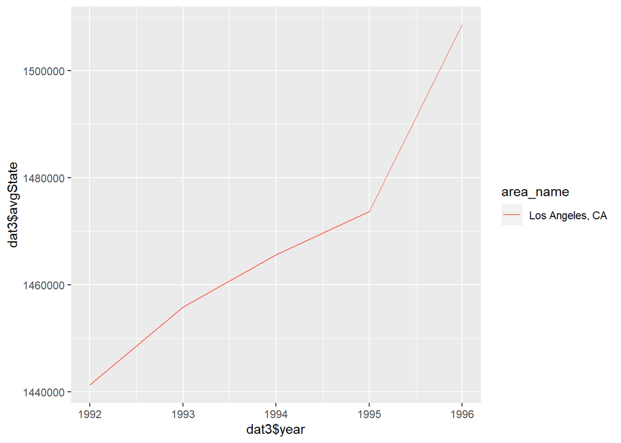

```r
plot.county <- function(df, area_name = ..., top = 5){
  dat2 <- df %>%
          select(area_name , year, enrolValue) %>%
          group_by(area_name, year) %>%
          summarise(avgState = mean(enrolValue)) %>%
          arrange(desc(avgState))

  dat3 <- head(dat2, n = top)

 plot <- ggplot(dat3, aes(x = dat3$year, y = dat3$avgState, color = area_name)) +
geom_line()

 return(list(dat2,dat3,plot))

}
plot.county(df = Both_combined[[1]])
```

#### Put it together

```r
## run the two cvs files given earlier in our function
wrap_a <- my_wrapper(("https://www4.stat.ncsu.edu/~online/datasets/EDU01a.csv"),var_name = 'enrollment')

wrap_b <- my_wrapper(("https://www4.stat.ncsu.edu/~online/datasets/EDU01b.csv"),var_name = 'enrollment')

## Combine the two objects above into one object with two data frames
Both_combined <- combine(x = wrap_a, y = wrap_b); Both_combined
```

```
## [[1]]
## # A tibble: 62,900 x 7
##    area_name   STCOU enrollment enrolValue surveyID  year var
##    <chr>       <chr> <chr>           <dbl> <chr>    <dbl> <chr>
##  1 Autauga, AL 01001 EDU010187D       6829 EDU0101   1987 01
##  2 Autauga, AL 01001 EDU010188D       6900 EDU0101   1988 01
##  3 Autauga, AL 01001 EDU010189D       6920 EDU0101   1989 01
##  4 Autauga, AL 01001 EDU010190D       6847 EDU0101   1990 01
##  5 Autauga, AL 01001 EDU010191D       7008 EDU0101   1991 01
##  6 Autauga, AL 01001 EDU010192D       7137 EDU0101   1992 01
##  7 Autauga, AL 01001 EDU010193D       7152 EDU0101   1993 01
##  8 Autauga, AL 01001 EDU010194D       7381 EDU0101   1994 01
##  9 Autauga, AL 01001 EDU010195D       7568 EDU0101   1995 01
## 10 Autauga, AL 01001 EDU010196D       7834 EDU0101   1996 01
## # ... with 62,890 more rows
##
## [[2]]
## # A tibble: 1,060 x 7
##    area_name     STCOU enrollment enrolValue surveyID  year division
##    <chr>         <chr> <chr>           <dbl> <chr>    <dbl> <chr>
##  1 UNITED STATES 00000 EDU010187D   40024299 EDU0101   1987 Error
##  2 UNITED STATES 00000 EDU010188D   39967624 EDU0101   1988 Error
##  3 UNITED STATES 00000 EDU010189D   40317775 EDU0101   1989 Error
##  4 UNITED STATES 00000 EDU010190D   40737600 EDU0101   1990 Error
##  5 UNITED STATES 00000 EDU010191D   41385442 EDU0101   1991 Error
##  6 UNITED STATES 00000 EDU010192D   42088151 EDU0101   1992 Error
##  7 UNITED STATES 00000 EDU010193D   42724710 EDU0101   1993 Error
##  8 UNITED STATES 00000 EDU010194D   43369917 EDU0101   1994 Error
##  9 UNITED STATES 00000 EDU010195D   43993459 EDU0101   1995 Error
## 10 UNITED STATES 00000 EDU010196D   44715737 EDU0101   1996 Error
## # ... with 1,050 more rows
```

```r
## Use the plot function on the 'state' data frame
plot_state <- plot.state(df = Both_combined[[2]]); plot_state
```

[output not shown]

- Run your data processing function on the four data sets at URLs given below

```r
newdata_a <- my_wrapper(("https://www4.stat.ncsu.edu/~online/datasets/PST01a.csv"),var_name = 'enrollment'); newdata_a
```

```
## [[1]]
## # A tibble: 31,450 x 7
##    area_name   STCOU enrollment enrolValue surveyID  year var
##    <chr>       <chr> <chr>           <dbl> <chr>    <dbl> <chr>
##  1 Autauga, AL 01001 EDU010187D       6829 EDU0101   1987 01
##  2 Autauga, AL 01001 EDU010188D       6900 EDU0101   1988 01
##  3 Autauga, AL 01001 EDU010189D       6920 EDU0101   1989 01
##  4 Autauga, AL 01001 EDU010190D       6847 EDU0101   1990 01
##  5 Autauga, AL 01001 EDU010191D       7008 EDU0101   1991 01
##  6 Autauga, AL 01001 EDU010192D       7137 EDU0101   1992 01
##  7 Autauga, AL 01001 EDU010193D       7152 EDU0101   1993 01
##  8 Autauga, AL 01001 EDU010194D       7381 EDU0101   1994 01
##  9 Autauga, AL 01001 EDU010195D       7568 EDU0101   1995 01
## 10 Autauga, AL 01001 EDU010196D       7834 EDU0101   1996 01
## # ... with 31,440 more rows
##
## [[2]]
## # A tibble: 530 x 7
##    area_name     STCOU enrollment enrolValue surveyID  year division
##    <chr>         <chr> <chr>           <dbl> <chr>    <dbl> <chr>
##  1 UNITED STATES 00000 EDU010187D   40024299 EDU0101   1987 Error
##  2 UNITED STATES 00000 EDU010188D   39967624 EDU0101   1988 Error
##  3 UNITED STATES 00000 EDU010189D   40317775 EDU0101   1989 Error
##  4 UNITED STATES 00000 EDU010190D   40737600 EDU0101   1990 Error
##  5 UNITED STATES 00000 EDU010191D   41385442 EDU0101   1991 Error
##  6 UNITED STATES 00000 EDU010192D   42088151 EDU0101   1992 Error
##  7 UNITED STATES 00000 EDU010193D   42724710 EDU0101   1993 Error
##  8 UNITED STATES 00000 EDU010194D   43369917 EDU0101   1994 Error
##  9 UNITED STATES 00000 EDU010195D   43993459 EDU0101   1995 Error
## 10 UNITED STATES 00000 EDU010196D   44715737 EDU0101   1996 Error
## # ... with 520 more rows
```

```r
newdata_b <- my_wrapper(("https://www4.stat.ncsu.edu/~online/datasets/PST01b.csv"),var_name = 'enrollment'); newdata_b
```

```
## [[1]]
## # A tibble: 31,450 x 7
##    area_name   STCOU enrollment enrolValue surveyID  year var
##    <chr>       <chr> <chr>           <dbl> <chr>    <dbl> <chr>
##  1 Autauga, AL 01001 EDU010187D       6829 EDU0101   1987 01
##  2 Autauga, AL 01001 EDU010188D       6900 EDU0101   1988 01
##  3 Autauga, AL 01001 EDU010189D       6920 EDU0101   1989 01
##  4 Autauga, AL 01001 EDU010190D       6847 EDU0101   1990 01
##  5 Autauga, AL 01001 EDU010191D       7008 EDU0101   1991 01
##  6 Autauga, AL 01001 EDU010192D       7137 EDU0101   1992 01
##  7 Autauga, AL 01001 EDU010193D       7152 EDU0101   1993 01
##  8 Autauga, AL 01001 EDU010194D       7381 EDU0101   1994 01
##  9 Autauga, AL 01001 EDU010195D       7568 EDU0101   1995 01
## 10 Autauga, AL 01001 EDU010196D       7834 EDU0101   1996 01
## # ... with 31,440 more rows
##
## [[2]]
## # A tibble: 530 x 7
##    area_name     STCOU enrollment enrolValue surveyID  year division
##    <chr>         <chr> <chr>           <dbl> <chr>    <dbl> <chr>
##  1 UNITED STATES 00000 EDU010187D   40024299 EDU0101   1987 Error
##  2 UNITED STATES 00000 EDU010188D   39967624 EDU0101   1988 Error
##  3 UNITED STATES 00000 EDU010189D   40317775 EDU0101   1989 Error
##  4 UNITED STATES 00000 EDU010190D   40737600 EDU0101   1990 Error
##  5 UNITED STATES 00000 EDU010191D   41385442 EDU0101   1991 Error
##  6 UNITED STATES 00000 EDU010192D   42088151 EDU0101   1992 Error
##  7 UNITED STATES 00000 EDU010193D   42724710 EDU0101   1993 Error
##  8 UNITED STATES 00000 EDU010194D   43369917 EDU0101   1994 Error
##  9 UNITED STATES 00000 EDU010195D   43993459 EDU0101   1995 Error
## 10 UNITED STATES 00000 EDU010196D   44715737 EDU0101   1996 Error
## # ... with 520 more rows
```

```r
newdata_c <- my_wrapper(("https://www4.stat.ncsu.edu/~online/datasets/PST01c.csv"),var_name = 'enrollment'); newdata_c
```

```
## [[1]]
## # A tibble: 31,450 x 7
##    area_name   STCOU enrollment enrolValue surveyID  year var
##    <chr>       <chr> <chr>           <dbl> <chr>    <dbl> <chr>
##  1 Autauga, AL 01001 EDU010187D       6829 EDU0101   1987 01
##  2 Autauga, AL 01001 EDU010188D       6900 EDU0101   1988 01
##  3 Autauga, AL 01001 EDU010189D       6920 EDU0101   1989 01
##  4 Autauga, AL 01001 EDU010190D       6847 EDU0101   1990 01
##  5 Autauga, AL 01001 EDU010191D       7008 EDU0101   1991 01
##  6 Autauga, AL 01001 EDU010192D       7137 EDU0101   1992 01
##  7 Autauga, AL 01001 EDU010193D       7152 EDU0101   1993 01
##  8 Autauga, AL 01001 EDU010194D       7381 EDU0101   1994 01
##  9 Autauga, AL 01001 EDU010195D       7568 EDU0101   1995 01
## 10 Autauga, AL 01001 EDU010196D       7834 EDU0101   1996 01
## # ... with 31,440 more rows
##
## [[2]]
## # A tibble: 530 x 7
##    area_name     STCOU enrollment enrolValue surveyID  year division
##    <chr>         <chr> <chr>           <dbl> <chr>    <dbl> <chr>
##  1 UNITED STATES 00000 EDU010187D   40024299 EDU0101   1987 Error
##  2 UNITED STATES 00000 EDU010188D   39967624 EDU0101   1988 Error
##  3 UNITED STATES 00000 EDU010189D   40317775 EDU0101   1989 Error
##  4 UNITED STATES 00000 EDU010190D   40737600 EDU0101   1990 Error
##  5 UNITED STATES 00000 EDU010191D   41385442 EDU0101   1991 Error
##  6 UNITED STATES 00000 EDU010192D   42088151 EDU0101   1992 Error
##  7 UNITED STATES 00000 EDU010193D   42724710 EDU0101   1993 Error
##  8 UNITED STATES 00000 EDU010194D   43369917 EDU0101   1994 Error
##  9 UNITED STATES 00000 EDU010195D   43993459 EDU0101   1995 Error
## 10 UNITED STATES 00000 EDU010196D   44715737 EDU0101   1996 Error
## # ... with 520 more rows
```

```r
newdata_d <- my_wrapper(("https://www4.stat.ncsu.edu/~online/datasets/PST01d.csv"),var_name = 'enrollment'); newdata_d
```

```
## [[1]]
## # A tibble: 31,450 x 7
##    area_name   STCOU enrollment enrolValue surveyID  year var
##    <chr>       <chr> <chr>           <dbl> <chr>    <dbl> <chr>
##  1 Autauga, AL 01001 EDU010187D       6829 EDU0101   1987 01
##  2 Autauga, AL 01001 EDU010188D       6900 EDU0101   1988 01
##  3 Autauga, AL 01001 EDU010189D       6920 EDU0101   1989 01
##  4 Autauga, AL 01001 EDU010190D       6847 EDU0101   1990 01
##  5 Autauga, AL 01001 EDU010191D       7008 EDU0101   1991 01
##  6 Autauga, AL 01001 EDU010192D       7137 EDU0101   1992 01
##  7 Autauga, AL 01001 EDU010193D       7152 EDU0101   1993 01
##  8 Autauga, AL 01001 EDU010194D       7381 EDU0101   1994 01
##  9 Autauga, AL 01001 EDU010195D       7568 EDU0101   1995 01
## 10 Autauga, AL 01001 EDU010196D       7834 EDU0101   1996 01
## # ... with 31,440 more rows
##
## [[2]]
## # A tibble: 530 x 7
##    area_name     STCOU enrollment enrolValue surveyID  year division
##    <chr>         <chr> <chr>           <dbl> <chr>    <dbl> <chr>
##  1 UNITED STATES 00000 EDU010187D   40024299 EDU0101   1987 Error
##  2 UNITED STATES 00000 EDU010188D   39967624 EDU0101   1988 Error
##  3 UNITED STATES 00000 EDU010189D   40317775 EDU0101   1989 Error
##  4 UNITED STATES 00000 EDU010190D   40737600 EDU0101   1990 Error
##  5 UNITED STATES 00000 EDU010191D   41385442 EDU0101   1991 Error
##  6 UNITED STATES 00000 EDU010192D   42088151 EDU0101   1992 Error
##  7 UNITED STATES 00000 EDU010193D   42724710 EDU0101   1993 Error
##  8 UNITED STATES 00000 EDU010194D   43369917 EDU0101   1994 Error
##  9 UNITED STATES 00000 EDU010195D   43993459 EDU0101   1995 Error
## 10 UNITED STATES 00000 EDU010196D   44715737 EDU0101   1996 Error
## # ... with 520 more rows
```

- Run your data combining function (probably three times) to put these into one object (with two data frames)

```r
combine_ab <- combine(x = newdata_a, y = newdata_b)
combine_cd <- combine(x = newdata_c, y= newdata_d)
combine_abcd <- combine(x= combine_ab, y = combine_cd)
combine_abcd
```

```
## [[1]]
## # A tibble: 125,800 x 7
##    area_name   STCOU enrollment enrolValue surveyID  year var
##    <chr>       <chr> <chr>           <dbl> <chr>    <dbl> <chr>
##  1 Autauga, AL 01001 EDU010187D       6829 EDU0101   1987 01
##  2 Autauga, AL 01001 EDU010188D       6900 EDU0101   1988 01
##  3 Autauga, AL 01001 EDU010189D       6920 EDU0101   1989 01
##  4 Autauga, AL 01001 EDU010190D       6847 EDU0101   1990 01
##  5 Autauga, AL 01001 EDU010191D       7008 EDU0101   1991 01
##  6 Autauga, AL 01001 EDU010192D       7137 EDU0101   1992 01
##  7 Autauga, AL 01001 EDU010193D       7152 EDU0101   1993 01
##  8 Autauga, AL 01001 EDU010194D       7381 EDU0101   1994 01
##  9 Autauga, AL 01001 EDU010195D       7568 EDU0101   1995 01
## 10 Autauga, AL 01001 EDU010196D       7834 EDU0101   1996 01
## # ... with 125,790 more rows
##
## [[2]]
## # A tibble: 2,120 x 7
##    area_name     STCOU enrollment enrolValue surveyID  year division
##    <chr>         <chr> <chr>           <dbl> <chr>    <dbl> <chr>
##  1 UNITED STATES 00000 EDU010187D   40024299 EDU0101   1987 Error
##  2 UNITED STATES 00000 EDU010188D   39967624 EDU0101   1988 Error
##  3 UNITED STATES 00000 EDU010189D   40317775 EDU0101   1989 Error
##  4 UNITED STATES 00000 EDU010190D   40737600 EDU0101   1990 Error
##  5 UNITED STATES 00000 EDU010191D   41385442 EDU0101   1991 Error
##  6 UNITED STATES 00000 EDU010192D   42088151 EDU0101   1992 Error
##  7 UNITED STATES 00000 EDU010193D   42724710 EDU0101   1993 Error
##  8 UNITED STATES 00000 EDU010194D   43369917 EDU0101   1994 Error
##  9 UNITED STATES 00000 EDU010195D   43993459 EDU0101   1995 Error
## 10 UNITED STATES 00000 EDU010196D   44715737 EDU0101   1996 Error
## # ... with 2,110 more rows
```

- Use the plot function on the state data frame

```r
plot_state_2 <- plot.state(df = combine_abcd[[2]]); plot_state_2
```

[output not shown]